# Fake News? Covid19 Fake News Detection

- Introduction
  - Problem Area
  - Objectives
  - Dataset
  - Evaluation methodology
- Implementation
  - Preprocessing
  - Baseline performance
- Conclusions
  - Results Evaluation
  - Conclusion
- Bibliography

## Introduction

### Problem Area

Fake news can be defined as inaccurate or otherwise misleading information that is growing both knowingly and unknowingly (Chen and Sin, 2013). With the rapid advancements in technology leading to the significance of social media to increase manifold, the online availability and hasty dissemination of ‘disinformation’ and ‘fake news’ have become a global threat over the past 10 years (Tucker et al., 2018).

Studies have shown that the spread of fake information on social media affects the reputation of many individuals and organisations (Cheng et al., 2020), while also causing mental and emotional stress (Began et al., 2005). Furthermore, Carson (2018) showed that most people in advanced economies would believe more fake news than truthful news by 2022.

Manual detection of fake news is a very reliable method. However it has limitations in terms of speed and it has become increasingly cumbersome and time-consuming due to the large volumes of content generated on the Internet. Such manual efforts can also be ineffective at times as fake news can be quicker to spread when compared to verified claims. This gave rise to false information recognition as an essential task in natural language processing (Throne and Vlachos, 2018).

To date, many automated misinformation detection architectures have been developed. While earlier methods use hand-crafted features based psycho-linguistics and n-grams (Perez-Rosas et. al., 2017) more recent studies rely on automatic extraction of relevant features in the form of distributed representations (Wang, 2017). Various machine learning approches are used in this field ranging from traditional supervised machine learning methods (Hossain et al., 2020, Khan et al, 2021, Vijjali et al., 2020) which classify the data as misleading or not by comparing the input text to an already existing corpora containing real and fake information (Elhadad et al., 2019) to state-of-the-art transformers (Morio et. al., 2020; Kar et al., 2020, Wu and Chien, 2020).

### Objectives

COVID- 19 is a contagious disease which caused havoc around the world. The pandemic is considered a global health crisis and thus a significant newsworthy event with related news being widespread on social media. Subsequently, misinformation has been especially prevalent during the ongoing COVID-19 pandemic, so much so that the World Health Organization (WHO) stated that the world was in a war to fight an "infodemic" along with a pandemic.

In light of the serious issue that surrounds COVID-19 fake news, this analysis aims to add to the ongoing research on fake news classification, focusing on COVID-19 social media posts to aid in the fight to curb the dissemination of fake news and support the spread of much needed factual information.

Fake news in relation to COVID-19 is a much bigger problem as it can influence people to accept and spread potentially deleterious claims and articles. For example, fake news claiming that alcohol is a cure for COVID-19 led to many deaths and hospitalisations in Iran (Karimi and Gambrell, 2020). Recent studies (Mazza et al., 2020) also show that there has been an increase in symptoms of anxiety and depression in connection with the pandemic, and as the spread fake news can be more successful when the population is experiencing a stressful psychological situation (Moscadelli et al., 2020), curbing fake news at the source and preventing it from spreading to a larger audience is crucial.

### Dataset

The dataset used was that developed by Patwa et al. (2020) in connection with the [ConstraintAI’21 shared task for Covid-19 fake news detection](https://constraint-shared-task-2021.github.io). The workshop was aimed to combat online hostile posts. The dataset was is freely available and was downloaded from the link provided. The dataset consists of 10,700 social media posts with predefined training (60%), validation (20%) and testing (20%) sets. Each dataset contains three columns; the id, textual social media posts and their corresponding label classification identifying whether the social media post is fake or real. The id is of type integer, while the social media posts and their corresponding labels are of type object.

The real news is collected from verified Twitter handles which give useful information regarding COVID-19 while the fake news were collected from various social media platforms including Twitter, Facebook and Instagram and verified to be fake by fact-checking websites.

### Evaluation methodology

To determine whether the method is successful, the metric **accuracy** is used. Accuracy measures the number of correct predictions over the total number of predictions and thus calculates the percent you predicted correctly. This was chosen over other performance metrics like precision, recall and F1 as accuracy works well for single label, binary classification problems with balanced classes such as this one.

## Implementation

```python
# Importing the libraries

# Basics

import numpy as np
import pandas as pd
import re
import string
import numpy as np
import csv
from tqdm import tqdm
import warnings
warnings.simplefilter(action='ignore', category=FutureWarning)

# Visualisations

import matplotlib.pyplot as plt
%matplotlib inline
import seaborn as sns
from PIL import Image
from os import path
from wordcloud import WordCloud, ImageColorGenerator

## Natural Language Processing
import nltk
#nltk.download('all')
from nltk import pos_tag
from nltk.tokenize import word_tokenize, sent_tokenize
from nltk.corpus import stopwords, wordnet
from nltk.stem.wordnet import WordNetLemmatizer

# Modelling
from sklearn.feature_extraction.text import CountVectorizer
from sklearn.feature_extraction.text import TfidfTransformer
from sklearn.feature_extraction.text import TfidfVectorizer
from sklearn.pipeline import Pipeline
from sklearn.naive_bayes import MultinomialNB
from sklearn.linear_model import  LogisticRegression
from sklearn.linear_model import SGDClassifier
from sklearn import svm
from sklearn.ensemble import RandomForestClassifier
from sklearn.metrics import confusion_matrix, f1_score, classification_report
from sklearn.model_selection import GridSearchCV
from sklearn.metrics import average_precision_score
from sklearn.metrics import accuracy_score, f1_score, precision_score, recall_score
import itertools
```

### Data analysis and Preprocessing

```python
# Importing Data

training_data = pd.read_csv("Constraint_English_Train.txt")
validation_data = pd.read_csv("Constraint_English_Val.txt")
testing_data = pd.read_csv("Constraint_English_Test.txt")
```

```
Training Set
<class 'pandas.core.frame.DataFrame'>
RangeIndex: 6420 entries, 0 to 6419
Data columns (total 3 columns):
 #   Column  Non-Null Count  Dtype
---  ------  --------------  -----
 0   id      6420 non-null   int64
 1   tweet   6420 non-null   object
 2   label   6420 non-null   object
dtypes: int64(1), object(2)
memory usage: 150.6+ KB
None
(6420, 3)


Validation Set
<class 'pandas.core.frame.DataFrame'>
RangeIndex: 2140 entries, 0 to 2139
Data columns (total 3 columns):
 #   Column  Non-Null Count  Dtype
---  ------  --------------  -----
 0   id      2140 non-null   int64
 1   tweet   2140 non-null   object
 2   label   2140 non-null   object
dtypes: int64(1), object(2)
memory usage: 50.3+ KB
None
(2140, 3)


Testing Set
<class 'pandas.core.frame.DataFrame'>
RangeIndex: 2140 entries, 0 to 2139
Data columns (total 3 columns):
 #   Column  Non-Null Count  Dtype
---  ------  --------------  -----
 0   id      2140 non-null   int64
 1   tweet   2140 non-null   object
 2   label   2140 non-null   object
dtypes: int64(1), object(2)
memory usage: 50.3+ KB
None
(2140, 3)
```

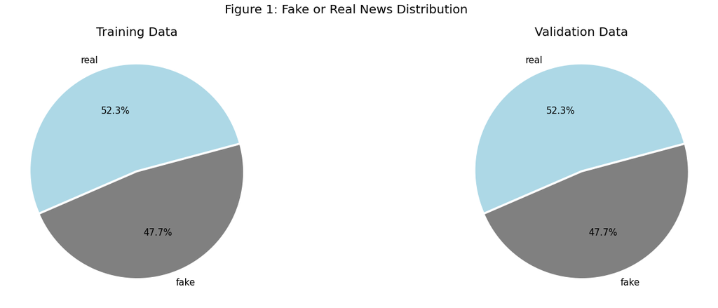

```python
# A quick overview of the datasets and seeing that there
# are no null values.

print('Training Set')
print(training_data.info())
print(training_data.shape)
print('\n')

print('Validation Set')
print(validation_data.info())
print(validation_data.shape)
print('\n')

print('Testing Set')
print(testing_data.info())
print(testing_data.shape)

# Construction pie charts to see class distribution
df_train = training_data['label'].value_counts()
df_valid = validation_data['label'].value_counts()
key = df_train.keys()
labels = key
explode=(0.01, 0.01)
my_colours = ['lightblue','grey']
textprops = {"fontsize":15}

s = []
for i in key:
    s.append(df_train[i])

t = []
for i in key:
    t.append(df_valid[i])


fig, axes = plt.subplots(1,2, figsize=(24,8))
fig.suptitle('Figure 1: Fake or Real News Distribution', fontsize=20)

axes[0].pie(s,labels = labels, autopct='%1.1f%%',startangle = 15, colors = my_colours, explode= explode, textprops = textprops)
axes[0].set_title('Training Data', fontsize = 20)

axes[1].pie(t,labels = labels,autopct='%1.1f%%',startangle = 15, colors = my_colours, explode= explode, textprops = textprops)
axes[1].set_title('Validation Data', fontsize = 20)
```

The above output shows that the training data consists of 6420 samples, with 52.3% being real news and 47.7% being fake news and the validation data consists of 2140 samples with 52.3% being real news and 47.7% being fake news. This shows that the distribution between the classes is balanced, ensuring that the performance metric 'accuracy' can be used.

Data preprocessing is the phase of preparing raw data to make it suitable for a machine learning model. In this analysis it included the following steps:

- The urls are removed and the words are deontracted. This is done as with many social media texts most words are contracted, which makes it harder for a machine learning model to recognise. Urls are also removed as they do not add significance to the analysis.
- The tweets are tokenized into sentences and represented as a list of words. The tweets are also transformed to lower case and newline characters are removed. This is done due to the case sensitive nature of NLP libraries and to aid lemmatization in the subsequent steps as well as remove the noisey text that occurs when there is a newline character.
- The tweets are lemmatized according to their POS tags to reduce the inflected words properly while still ensuring that the root word belongs to the language.
- Special characters and stop words are removed. This is done as special characters are not readable and stopwords, i.e. the words that commonly occur in the English language usually do not add meaning to text.

```python
#Defining stop_words
stop_words = set(stopwords.words("english"))

# Defining lemmatizer
lemmatizer = WordNetLemmatizer()


def decontract_and_deweb(tweet):

    """
    Reads in a raw tweet and returns the string without urls and with decontract words

    """
    # tweet is decontracted and urls are removed
    tweet = re.sub(r"won\'t", "will not", tweet)
    tweet = re.sub(r"can\'t", "can not", tweet)
    tweet = re.sub(r"n\'t", " not", tweet)
    tweet = re.sub(r"\'re", " are", tweet)
    tweet = re.sub(r"\'s", " is", tweet)
    tweet = re.sub(r"\'d", " would", tweet)
    tweet = re.sub(r"\'ll", " will", tweet)
    tweet = re.sub(r"\'t", " not", tweet)
    tweet = re.sub(r"\'ve", " have", tweet)
    tweet = re.sub(r"\'m", " am", tweet)
    tweet = re.sub(r"http(\S)+",' ',tweet)
    tweet = re.sub(r"www(\S)+",' ',tweet)

    return tweet

def tweet_tokenizer(tweet):

    """
    Reads in a raw tweet and returns a list of sentences represented as a list of words.
    Tweet is also converted to lower_case and newline characters are removed.

    """
    tweet = tweet.replace('\\n',' ').lower()
    sentences = re.compile('[.!?] ').split(tweet)
    tweet_tokens = [sentence.split() for sentence in sentences]
    return tweet_tokens

def get_wordnet_pos(treebank_tag):

    """
    Converts a treebank POS tag to a wordnet POS tag.

    """
    if treebank_tag.startswith('J'):
        tag = wordnet.ADJ
    elif treebank_tag.startswith('V'):
        tag = wordnet.VERB
    elif treebank_tag.startswith('N'):
        tag = wordnet.NOUN
    elif treebank_tag.startswith('R'):
        tag = wordnet.ADV
    else:
        tag = ''
    return tag

def sentence_pos_tagger(sentence):
    """
    Takes a sentence as a list of tokens and returns a
    list of wordnet POS tagged tokens.

    """
    treebank_tags = pos_tag(sentence)
    wordnet_tags = [
        (treebank_tag[0], get_wordnet_pos(treebank_tag[1])) for treebank_tag in treebank_tags
    ]
    return wordnet_tags

def tweet_pos_tagger(tweet_tokens):
    """
    Takes a tokenized tweet and returns POS tagged tokens.

    """
    pos_tags = [
        sentence_pos_tagger(sentence) for sentence in tweet_tokens
    ]
    return pos_tags

def tag_lemmatizer(pos_tag):
    """
    Takes a POS tagged word and returns its Lemma.

    """
    if pos_tag[1] != '':
        lemmatized_word = lemmatizer.lemmatize(pos_tag[0], pos_tag[1])
    else:
        lemmatized_word = pos_tag[0]
    return lemmatized_word

def sentence_lemmatizer(sentence_tags):
    """
    Takes a POS tagged sentence and lemmatizes.

    """
    lemmatized_sentence = [
        tag_lemmatizer(pos_tag) for pos_tag in sentence_tags
    ]
    return lemmatized_sentence

def tweet_lemmatizer(tweet_tags):
    """
    Lemmatize tagged words from a tweet and flatten sentence nesting.

    """
    lemmatized_tweet = []
    for sentence_tags in tweet_tags:
        lemmatized_sentence = sentence_lemmatizer(sentence_tags)
        lemmatized_tweet.extend(lemmatized_sentence)
    return lemmatized_tweet

def tweet_clean(lemmatized_tweet):
    """
    Takes a lemmatized tweet, drops special characters and stopwords

    """
    my_stopwords = stopwords.words('english')
    processed_tweet = [
        word for word in lemmatized_tweet
        if word.isalpha() and word not in my_stopwords
        and len(word)>1
    ]
    return processed_tweet

def tweet_processor(tweet):
    """
    Executes full data processing pipeline on a tweet
    """
    tweet = decontract_and_deweb(tweet)
    tweet_tokens = tweet_tokenizer(tweet)
    tweet_tags = tweet_pos_tagger(tweet_tokens)
    lemmatized_tweet = tweet_lemmatizer(tweet_tags)
    processed_tweet = tweet_clean(lemmatized_tweet)
    return processed_tweet
```

```python
# Applying the pipeline to all datasets

training_data['tweet'] = training_data['tweet'].map(lambda x: tweet_processor(x))
validation_data['tweet'] = validation_data['tweet'].map(lambda x: tweet_processor(x))
testing_data['tweet'] = testing_data['tweet'].map(lambda x: tweet_processor(x))
```

```python
# Generating a dataset with all data and datasets with fake tweets and real tweets
dataset = pd.concat([training_data, validation_data, testing_data])
fake = dataset[dataset['label']=='fake']
real = dataset[dataset['label']=='real']
```

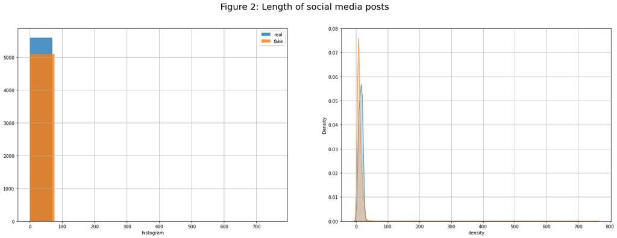

```python
# Generating histograms and density plots for word analysis

dataset["Length"] = dataset.tweet.map(len)

x, y = "Length", "label"
fig, ax = plt.subplots(1, 2, figsize=(24,8))
fig.suptitle("Figure 2: Length of social media posts", fontsize=20)
for i in dataset[y].unique():
    sns.distplot(dataset[dataset[y]==i][x], hist=True, kde=False,
                 bins=10, hist_kws={"alpha":0.8},
                 axlabel="histogram", ax=ax[0])
    sns.distplot(dataset[dataset[y]==i][x], hist=False, kde=True,
                 kde_kws={"shade":True}, axlabel="density",
                 ax=ax[1])
ax[0].grid(True)
ax[0].legend(dataset[y].unique())
ax[1].grid(True)
plt.show()
```

```python
# Analysing the total words in fake tweets and real tweets
positiveCloud = ""
for i in real['tweet']:
    positiveCloud += " ".join(i)+" "
print("Total words in real texts: ", len(positiveCloud))


negativeCloud = ""
for i in fake['tweet']:
    negativeCloud += " ".join(i)+" "
print("Total words in fake texts: ", len(negativeCloud))
```

```
Total words in real texts:  548966
Total words in fake texts:  368179
```

```python
# More in depth word analysis

def get_words_count(tweet):
    return len(re.split(' |,', ' '.join(tweet)))

words_avg_real = np.vectorize(get_words_count)(real['tweet']).mean()
words_avg_fake = np.vectorize(get_words_count)(fake['tweet']).mean()
print("Average words per real tweet: ", words_avg_real)
print("Average words per fake tweet: ", words_avg_fake, '\n')

max_words_real = np.vectorize(get_words_count)(real['tweet']).max()
max_words_fake = np.vectorize(get_words_count)(fake['tweet']).max()
print("Maximum no. of words in a real tweet: ", max_words_real)
print("Maximum no. of words in a fake tweet: ", max_words_fake, '\n')

min_words_real = np.vectorize(get_words_count)(real['tweet']).min()
min_words_fake = np.vectorize(get_words_count)(fake['tweet']).min()
print("Minimum no. of words in a real tweet: ", min_words_real)
print("Minimum no. of words in a fake tweet: ", min_words_fake, '\n')
```

```
Average words per real tweet:  14.309285714285714
Average words per fake tweet:  10.43

Maximum no. of words in a real tweet:  698
Maximum no. of words in a fake tweet:  758

Minimum no. of words in a real tweet:  1
Minimum no. of words in a fake tweet:  1
```

#### Table 1:

[output not shown]

Figure 2 above shows density plots and histograms which were generated to ensure that the word count of fake social media posts and real social media posts do not differ significantly. More in depth word analysis can be found in Table 1. It is observed that real social media posts contain more words per tweet and more total words. This could be due to the fact that verified sources they to post longer, more detailed posts. Word clouds, seen in Figure 3 and Figure 4 were generated showing the most common words in fake and real social media posts. From the figures, one can analyse that the fake social media posts has more words with a negative connotation. However there are common words among the two.

```python
# Generating a word cloud for fake and real news

def disp_wordcloud(cloud):

    """
    Produces a word cloud with title
    """
    wc = WordCloud(width = 800, height = 800,
                background_color ='white',
                stopwords = stop_words,
                min_font_size = 10).generate(cloud)
    plt.figure(figsize=(7,7), facecolor = None)
    plt.imshow(wc)
    plt.axis('off')
    plt.tight_layout(pad = 0)

    if cloud == positiveCloud:
        plt.title('Figure 3: Real Social Media Posts Word Cloud', fontsize = 20)
    else:
        plt.title('Figure 4: Fake Social Media Posts Word Cloud', fontsize = 20)
    plt.show()
    print()
```

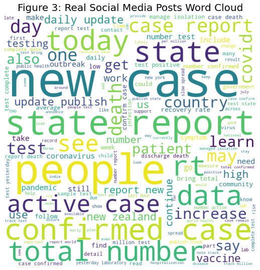

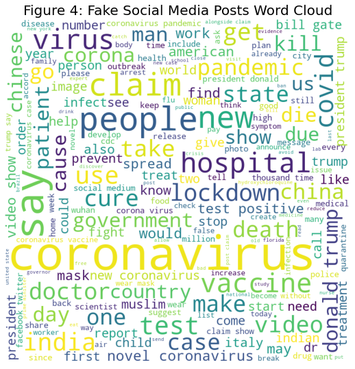

```python
disp_wordcloud(positiveCloud)
disp_wordcloud(negativeCloud)
```

```python
# Binarize Target variable - replace 'real' with 1 and 'fake' with 0
training_data["label"] = training_data["label"].map({"fake": 0, "real": 1})
validation_data["label"] = validation_data["label"].map({"fake": 0, "real": 1})
testing_data["label"] = testing_data["label"].map({"fake": 0, "real": 1})
```

```python
# Setting X (predictor) and y (target) variables

y_train = training_data['label']
y_val = validation_data['label']
y_test = testing_data['label']
X_train = training_data['tweet']
X_val = validation_data['tweet']
X_test = testing_data ['tweet']
```

#### Feature Extraction

Prior to training an algorithm to classify fake news, features need to be extracted. This means reducing the mass of unstructured data into some uniform set of attributes that an algorithm can understand. In this analysis Bag-of-Words approach and Term frequency-Inverse Document Frequency (TF-IDF) approach are analysed.

```python
# Initialising bag of words
# Count_vectorizer 'learns' the text vocabulary by using the 'fit' command.

count_vectorizer = CountVectorizer(analyzer=lambda x: x)
count_vectorizer.fit(X_train)

# The text is transformed into an array of word counts using the transform() function
vectorized = count_vectorizer.transform(X_train)

print(dict(list(count_vectorizer.vocabulary_.items())[0:10]))
print('The transformed data matrix dimensions:', vectorized.shape)

# So now we have a data matrix for the 6420 (rows) and 8006 distinct words (columns).
```

```
{'cdc': 1087, 'currently': 1720, 'report': 6014, 'death': 1787, 'general': 2930, 'discrepancy': 2029, 'count': 1620, 'different': 1983, 'source': 6687, 'small': 6615}
The transformed data matrix dimensions: (6420, 8006)
```

```python
# Initialising tf-idf
# Tf-idf_vectorizer 'learns' the text vocabulary by using the 'fit' command.
tfidf_vectorizer = TfidfVectorizer(analyzer=lambda x: x)
tfidf_vectorizer.fit(X_train)

# The text is transformed into an array of word counts using the transform() function
transformed_tfidf = tfidf_vectorizer.transform(X_train)
print(transformed_tfidf.shape)
```

```
(6420, 8006)
```

The dataset is divided into training, validation and testing data. The training dataset trains the models, while the validation dataset allows us to measure the performance of the model and better the model through hyperparameter tuning. The test dataset is used to analyse how well the final model generalizes to unseen data.

### Baseline performance

**Naïve Bayes** is a classification method based on Bayes’ theorem that derives the probability of the given feature vector being associated with a label. Naïve Bayes has a naive assumption of conditional independence for every feature, which means that the algorithm expects the features to be independent which not always is the case. Naive Bayes models the joint distribution of the feature X and target Y and then predicts the posterior probability given as P(y|x). Due to these characteristics, Naive Bayes is a very common baseline for text classification tasks, and the baseline used in this analysis. For the baseline, bag-of-words feature extraction is used.

```python
NB_pipeline = Pipeline([
        ('nbcv', count_vectorizer),
        ('nb',MultinomialNB())
        ])

NB_pipeline.fit(X_train,y_train)
NB_pred = NB_pipeline.predict(X_val)
accuracy = accuracy_score(NB_pred, y_val);
print('Accuracy is {:.2f} %'.format(accuracy*100))
```

```
Accuracy is 89.58 %
```

### Classification Approch

The results of the baseline are compared to various other machine learning models; Logistic Regression classifier (LR), Support Vector Machine (SVM), Stochastic Gradient Descent (SGD) and Random Forest (RF). Bag-of-words and Term frequency-Inverse Document Frequency (TF-IDF) feature extraction methods are used and the results are compared.

#### Logistic Regression

**Logistic Regression** is a linear classification method that learns the probability of a sample belonging to a certain class.

##### Using Bag of words

```python
LR_pipeline = Pipeline([
        ('logrcv',count_vectorizer),
        ('logr',LogisticRegression())
        ])

LR_pipeline.fit(X_train,y_train)
LR_pred = LR_pipeline.predict(X_val)
accuracy = accuracy_score(LR_pred, y_val)
print('Accuracy is {:.2f} %'.format(accuracy*100))
```

```
Accuracy is 90.89 %
```

##### Using tf-idf

```python
LR_pipeline_tfidf = Pipeline([
        ('logrtfidf',tfidf_vectorizer),
        ('logr',LogisticRegression())
        ])

LR_pipeline_tfidf.fit(X_train,y_train)
LR_pred_tfidf = LR_pipeline_tfidf.predict(X_val)
accuracy = accuracy_score(LR_pred_tfidf, y_val)
print('Accuracy is {:.2f} %'.format(accuracy*100))
```

```
Accuracy is 90.33 %
```

#### Linear SVM classifier

**Support Vector Machines** is a discriminative classifier formally defined by a separating hyperplane.

##### Using Bag of words

```python
SVM_pipeline = Pipeline([
        ('svmcv', count_vectorizer),
        ('svm',svm.LinearSVC())
        ])

SVM_pipeline.fit(X_train,y_train)
SWM_pred = SVM_pipeline.predict(X_val)
accuracy = accuracy_score(SWM_pred, y_val);
print('Accuracy is {:.2f} %'.format(accuracy*100))
```

```
Accuracy is 88.83 %
```

##### Using tf-idf

```python
SVM_pipeline_tfidf = Pipeline([
        ('svmtfidf', tfidf_vectorizer),
        ('svm',svm.LinearSVC())
        ])

SVM_pipeline_tfidf.fit(X_train,y_train)
SWM_pred_tfidf = SVM_pipeline.predict(X_val)
accuracy = accuracy_score(SWM_pred_tfidf, y_val);
print('Accuracy is {:.2f} %'.format(accuracy*100))
```

```
Accuracy is 88.83 %
```

#### SGD classifier

The **Stochastic Gradient Descent** used is a linear classifier (SVM) with SGD training. The gradient of the loss is estimated each sample at a time and the model is updated along the way with a decreasing strength schedule (aka learning rate).

##### Using bag of words

```python
SGD_pipeline = Pipeline([
        ('sgdcv', count_vectorizer),
        ('sgd',SGDClassifier(loss='hinge', penalty='l2', alpha=1e-3))
        ])

SGD_pipeline.fit(X_train,y_train)
SGD_pred = SGD_pipeline.predict(X_val)
accuracy = accuracy_score(SGD_pred, y_val);
print('Accuracy is {:.2f} %'.format(accuracy*100))
```

```
Accuracy is 90.23 %
```

##### Using tf-idf

```python
SGD_pipeline_tfidf = Pipeline([
        ('sgdtfidf', tfidf_vectorizer),
        ('sgd',SGDClassifier(loss='hinge', penalty='l2', alpha=1e-3))
        ])

SGD_pipeline_tfidf.fit(X_train,y_train)
SGD_pred_tfidf = SGD_pipeline_tfidf.predict(X_val)
accuracy = accuracy_score(SGD_pred_tfidf, y_val);
print('Accuracy is {:.2f} %'.format(accuracy*100))
```

```
Accuracy is 89.49 %
```

#### Random forest classifier

**Random forests** are an ensemble learning method that operates by constructing a multitude of decision trees at training time and outputting the class that is the mode of the classes (in the case of classification problem like this one).

##### Using bag of words

```python
RF_pipeline = Pipeline([
        ('rfcv',count_vectorizer),
        ('rf',RandomForestClassifier(n_estimators=200,n_jobs=3))
        ])

RF_pipeline.fit(X_train, y_train)
RF_pred = RF_pipeline.predict(X_val)
accuracy = accuracy_score(RF_pred, y_val);
print('Accuracy is {:.2f} %'.format(accuracy*100))
```

```
Accuracy is 89.72 %
```

##### Using tf-idf

```python
RF_pipeline_tfidf = Pipeline([
        ('rftfidf',tfidf_vectorizer),
        ('rf',RandomForestClassifier(n_estimators=300,n_jobs=3))
        ])

RF_pipeline_tfidf.fit(X_train, y_train)
RF_pred_tfidf = RF_pipeline_tfidf.predict(X_val)
accuracy = accuracy_score(RF_pred_tfidf, y_val);
print('Accuracy is {:.2f} %'.format(accuracy*100))
```

```
Accuracy is 89.95 %
```

#### Naive Bayes classifier

##### Using tf-idf

```python
NB_pipeline_tfidf = Pipeline([
        ('nbtfidf', tfidf_vectorizer),
        ('nb',MultinomialNB())
        ])

NB_pipeline_tfidf.fit(X_train,y_train)
NB_pred_tfidf = NB_pipeline_tfidf.predict(X_val)
accuracy = accuracy_score(NB_pred_tfidf, y_val);
print('Accuracy is {:.2f} %'.format(accuracy*100))
```

```
Accuracy is 89.53 %
```

The results of the above models can be seen in Table 2 below:

[output not shown]

```python
lr_parameters = {'logrcv__ngram_range': [(1, 1), (1, 2),(1,3),(1,4),(1,5)], #ngram
               'logr__C': [0.01, 1] } #penalty


gs = GridSearchCV(LR_pipeline, param_grid = lr_parameters)
gs.fit(X_train,y_train);

print("Best score:", gs.best_score_)
print("Train score", gs.score(X_train, y_train))
print("Validation score", gs.score(X_val, y_val))

gs.best_params_
```

```
Best score: 0.9038940809968847
Train score 0.9820872274143302
Validation score 0.9088785046728972
```

```
{'logr__C': 1, 'logrcv__ngram_range': (1, 1)}
```

```python
sgd_parameters ={'sgd__alpha': [1e-4, 1e-3, 1e-2, 1e-1, 1e-0, 1e-1, 1e-2, 1e-3]} # learning rate

gs = GridSearchCV(SGD_pipeline, param_grid = sgd_parameters)
gs.fit(X_train,y_train);

print("Best score:", gs.best_score_)
print("Train score", gs.score(X_train, y_train))
print("Validation score", gs.score(X_val, y_val))

gs.best_params_
```

```
Best score: 0.9007788161993769
Train score 0.9691588785046729
Validation score 0.9046728971962616
```

```
{'sgd__alpha': 0.001}
```

The results from hyperparameter tuning indicate that there was not a lot of improvement when adjusting the hyperparameters. The models are then run on the test data.

#### Logistic Regression

##### Using Bag of words

```python
LR_pipeline.fit(X_train,y_train)
LR_pred = LR_pipeline.predict(X_test)
accuracy = accuracy_score(LR_pred, y_test)
print('Accuracy is {:.2f} %'.format(accuracy*100))
```

```
Accuracy is 91.45 %
```

##### Using tf-idf

```python
LR_pipeline_tfidf.fit(X_train,y_train)
LR_pred_tfidf = LR_pipeline_tfidf.predict(X_test)
accuracy = accuracy_score(LR_pred_tfidf, y_test)
print('Accuracy is {:.2f} %'.format(accuracy*100))
```

```
Accuracy is 90.42 %
```

#### Linear SVM classifier

##### Using Bag of words

```python
SVM_pipeline.fit(X_train,y_train)
SWM_pred = SVM_pipeline.predict(X_test)
accuracy = accuracy_score(SWM_pred, y_test)
print('Accuracy is {:.2f} %'.format(accuracy*100))
```

```
Accuracy is 90.42 %
```

##### Using tf-idf

```python
SVM_pipeline_tfidf.fit(X_train,y_train)
SWM_pred_tfidf = SVM_pipeline.predict(X_test)
accuracy = accuracy_score(SWM_pred_tfidf, y_test)
print('Accuracy is {:.2f} %'.format(accuracy*100))
```

```
Accuracy is 90.42 %
```

#### SGD classifier

##### Using bag of words

```python
SGD_pipeline.fit(X_train,y_train)
SGD_pred = SGD_pipeline.predict(X_test)
accuracy = accuracy_score(SGD_pred, y_test);
print('Accuracy is {:.2f} %'.format(accuracy*100))
```

```
Accuracy is 90.93 %
```

##### Using tf-idf

```python
SGD_pipeline_tfidf.fit(X_train,y_train)
SGD_pred_tfidf = SGD_pipeline_tfidf.predict(X_test)
accuracy = accuracy_score(SGD_pred_tfidf, y_test);
print('Accuracy is {:.2f} %'.format(accuracy*100))
```

```
Accuracy is 89.39 %
```

#### Random forest classifier

##### Using bag of words

```python
RF_pipeline.fit(X_train, y_train)
RF_pred = RF_pipeline.predict(X_test)
accuracy = accuracy_score(RF_pred, y_test);
print('Accuracy is {:.2f} %'.format(accuracy*100))
```

```
Accuracy is 90.19 %
```

##### Using tf-idf

```python
RF_pipeline_tfidf.fit(X_train, y_train)
RF_pred_tfidf = RF_pipeline_tfidf.predict(X_test)
accuracy = accuracy_score(RF_pred_tfidf, y_test);
print('Accuracy is {:.2f} %'.format(accuracy*100))
```

```
Accuracy is 89.95 %
```

#### Naive Bayes classifier

##### Using bag of words

```python
NB_pipeline.fit(X_train,y_train)
NB_pred = NB_pipeline.predict(X_test)
accuracy = accuracy_score(NB_pred, y_test);
print('Accuracy is {:.2f} %'.format(accuracy*100))
```

```
Accuracy is 89.16 %
```

##### Using tf-idf

```python
NB_pipeline_tfidf.fit(X_train,y_train)
NB_pred_tfidf = NB_pipeline_tfidf.predict(X_test)
accuracy = accuracy_score(NB_pred_tfidf, y_test);
print('Accuracy is {:.2f} %'.format(accuracy*100))
```

```
Accuracy is 89.07 %
```

## Conclusions

### Results Evaluations

The results of the above models can be seen in Table 3 below:

#### Table 3:

|  | Bag-of-words | Tf-idf |
| --- | --- | --- |
| Naïve Bayes | 89.2% (Baseline) | 89.1% |
| Logistic Regression | 91.5% | 90.4% |
| Support Vector Machines | 90.4% | 90.4% |
| Stochastic Gradient Descent | 90.9% | 89.4% |
| Random forests | 90.2% | 90.0% |

The experiments confirmed that all machine learning algorithms were successfully in beating the baseline model of Naive Bayes with Logistic Regression and Stochastic Gradient Descent outperforming the baseline with a difference of close to 2 per cent in accuracy .

### Conclusion

In this work a simple but effective approach to COVID-19 fake news detection was proposed. Our pre-processing pipeline consisted of steps like stop word and noise removal, lemmatization and more. The classification approach was based on machine learning models Logistic Regression classifier, Support Vector Machine, Stochastic Gradient Descent and Random Forest which were compared to the baseline of Naive Bayes. All models proved to be an improvement on the baseline and the work is reproducible.

Further work can include the addition of further linguistic features that can increase the predictive power of an interpretable model to match that of black box models. The work can also be expanded upon by collecting more data, enriching the data by providing the reason for being real/fake along with the labels, and collecting multilingual data.

## Bibliography

Carson, J., 2018. Fake news: What exactly is it–and how can you spot it?. The Telegraph, 28.

Chen, X. and Sin, S.C.J., 2013. ‘Misinformation? What of it?’Motivations and individual differences in misinformation sharing on social media. Proceedings of the American Society for Information Science and Technology, 50(1), pp.1-4.

Cheng, Y. and Chen, Z.F., 2020. The influence of presumed fake news influence: examining public support for corporate corrective response, media literacy interventions, and governmental regulation. Mass Communication and Society, 23(5), pp.705-729.

Elhadad, M.K., Li, K.F. and Gebali, F., 2019, November. A novel approach for selecting hybrid features from online news textual metadata for fake news detection. In International Conference on P2P, Parallel, Grid, Cloud and Internet Computing (pp. 914-925). Springer, Cham.

Hossain, T., Logan IV, R.L., Ugarte, A., Matsubara, Y., Singh, S. and Young, S., 2020. Detecting covid-19 misinformation on social media.

Kar, D., Bhardwaj, M., Samanta, S. and Azad, A.P., 2020. No rumours please! A multi-indic-lingual approach for COVID fake-tweet detection. arXiv preprint arXiv:2010.06906.

Karimi, N. and Gambrell, J., 2020. Hundreds die f poisoning in Iran as fake news suggests methanol cure for virus. Times of Israel.

Khan, J.Y., Khondaker, M.T.I., Afroz, S., Uddin, G. and Iqbal, A., 2021. A benchmark study of machine learning models for online fake news detection. Machine Learning with Applications, 4, p.100032.

Mazza, C., Ricci, E., Biondi, S., Colasanti, M., Ferracuti, S., Napoli, C. and Roma, P., 2020. A nationwide survey of psychological distress among Italian people during the COVID-19 pandemic: immediate psychological responses and associated factors. International journal of environmental research and public health, 17(9), p.3165.

Morio, G., Morishita, T., Ozaki, H. and Miyoshi, T., 2020, December. Hitachi at SemEval-2020 Task 11: An empirical study of pre-trained transformer family for propaganda detection. In Proceedings of the Fourteenth Workshop on Semantic Evaluation (pp. 1739-1748).

Moscadelli, A., Albora, G., Biamonte, M.A., Giorgetti, D., Innocenzio, M., Paoli, S., Lorini, C., Bonanni, P. and Bonaccorsi, G., 2020. Fake news and covid-19 in Italy: results of a quantitative observational study. International journal of environmental research and public health, 17(16), p.5850.

Patwa, P., Sharma, S., Pykl, S., Guptha, V., Kumari, G., Akhtar, M.S., Ekbal, A., Das, A. and Chakraborty, T., 2021, February. Fighting an infodemic: Covid-19 fake news dataset. In International Workshop on Combating On line Ho st ile Posts in Regional Languages dur ing Emerge ncy Si tuation (pp. 21-29). Springer, Cham.

Pérez-Rosas, V., Kleinberg, B., Lefevre, A. and Mihalcea, R., 2017. Automatic detection of fake news. arXiv preprint arXiv:1708.07104.

Thorne, J. and Vlachos, A., 2018. Automated fact checking: Task formulations, methods and future directions. arXiv preprint arXiv:1806.07687.

Tucker, J.A., Guess, A., Barberá, P., Vaccari, C., Siegel, A., Sanovich, S., Stukal, D. and Nyhan, B., 2018. Social media, political polarization, and political disinformation: A review of the scientific literature. Political polarization, and political disinformation: a review of the scientific literature (March 19, 2018).

Vijjali, R., Potluri, P., Kumar, S. and Teki, S., 2020. Two stage transformer model for covid-19 fake news detection and fact checking. arXiv preprint arXiv:2011.13253.

Wang, W.Y., 2017. " liar, liar pants on fire": A new benchmark dataset for fake news detection. arXiv preprint arXiv:1705.00648.

Wu, S.H. and Chien, S.L., 2020. A BERT based Two-stage Fake News Spreader Profiling System. In CLEF (Working Notes).